# Tree Cavity Estimation by Decay Class

Jeff Matheson

2020-09-05

# Introduction

This is a supplementary analysis to the Tree Cavity Estimation. The purpose is to further explore the snag data.

**NOTE: The R code can be hidden using the pull-down menu in the top right.**

# Snag Decay Class Estimation

Estimated number of snags by decay class by structural stage. Will leave out the SMR and stand composition as there likely won’t be enough samples to fit a model.

## Setup and Data Prep

All data is in “snag_data.xlsx”.

```r
# Packages and Options
library(here)
library(tidyverse)
library(readxl)
library(vcd)
library(MASS)
library(visreg)
library(MuMIn)
library(effects)
library(DHARMa)
library(emmeans)
library(broom)
library(broomExtra)
library(ggpubr)

options(scipen = 999)    # Force not to use scientific notation for numberss.
```

```r
# Read and Prepare Data
snag_dat <-
  read_xlsx(here("cavity_trees", "dat", "snag_data.xlsx"),
                      sheet = "SN11_long") %>%
  mutate(Structural_Stage = case_when(
    Structural_Stage == "2" ~ "Herb",
    Structural_Stage == "3" ~ "Shrub",
    Structural_Stage == "4" ~ "P-S",
    Structural_Stage == "5" ~ "Young",
    Structural_Stage == "6" ~ "Mature",
    Structural_Stage == "7" ~ "Old")
    ) %>%
  mutate(Structural_Stage = factor(Structural_Stage,
                                   levels = c("Herb", "Shrub", "P-S", "Young", "Mature", "Old")),
         Stand_Composition = factor(Stand_Composition),
         SMR = factor(SMR, levels = c("dry", "mesic", "moist", "wet")),
         Decay_Class = factor(Decay_Class,
                              levels = c("Class2", "Class3", "Class4", "Class5", "Class6", "Class7", "Class8"))
         )
```

## Fit Model

Summarize data by Structral Stage and Decay Class:

```r
snag_total <- snag_dat %>%
  filter(Structural_Stage != "Herb") %>%
  droplevels() %>%
  group_by(HabDat_ID, Structural_Stage, Decay_Class) %>%
  summarize(count_total = sum(Count))
```

Data fits negative binomial distribution:

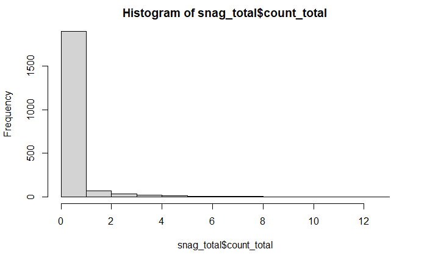

```r
hist(snag_total$count_total)
```

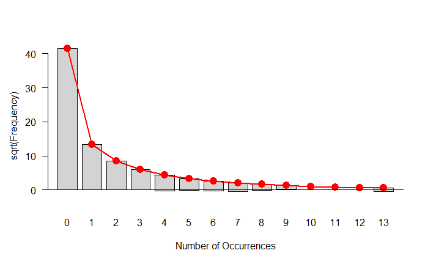

```r
fit_nbinom <- goodfit(snag_total$count_total, type = "nbinomial")
rootogram(fit_nbinom)
```

Fit GLM with negative binomial distribution.  
Only fitting model with oe variable.

Model fitting mechanics is different with grouped data. Will use the tidyverse way. {broomExtra} package also has some important tools. See:  
[R for Data Science](https://r4ds.had.co.nz/many-models.html)  
[Broom and Tidy](https://cran.r-project.org/web/packages/broom/vignettes/broom_and_dplyr.html)

```r
# Nest the data
decay_nest <- snag_total %>%
  nest(data = c(HabDat_ID, Structural_Stage, count_total))

# Create a function with the model that will be applied across all nested subsets.
decay_model <- function(df) {
  glm.nb(count_total ~ Structural_Stage, data = df)
}
# Use purrr::map to iterate
model_out <- map(decay_nest$data, decay_model)
```

Marignal means and confidence intervals added using emmeans. Note use of of ~ (lambda) to define an anonymous function for emmeans for use in map.

Use ‘unnest’ to unest whatever variables are of interest.

# Visualize

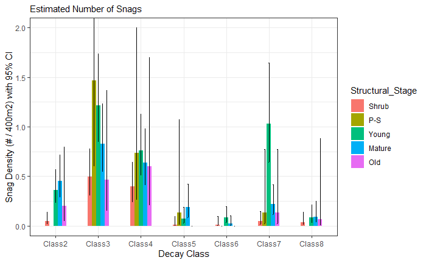